# mm_crypto

*A predictive algorithm for cryptocurrency market making*

1. Introduction
2. Input parameters, data, and dependencies
3. Prediction of fair value
4. Spread estimation
5. Conclusions
6. References

# Introduction

This document details a procedure to investigate if it is possible to predict the fair value of a cryptocurrency by using its limit order book data and the respective market data (trades).

## Hypotheses and assumptions

### Historical limit order-book (LOB) probability distribution

The probability distribution of an order at depth $D$ of the order book being executed is assumed to be a Poisson distribution.  
Using such a distribution, the probability of a limit order at $D > 10$ being hit is negligible (p = 0.00045). We will therefore consider only the first 10 levels of the historical LOBs. This also has the benefit of speeding up the calculations.

### Definition of fair value

The instantaneous fair value is assumed to be the arithmetic average of the bid and ask price at the top of the LOB (level 0), usually referred to as mid-price.  
The predicted fair value is based on the same convention. Since the fair value is the variable we want to predict, it will equivalently be referred to as "target" in the rest of this document.

### Frequency of historical data

The frequency of the historical data available is not constant, that is, the time delta between $LOB_i$ and $LOB_{i-1}$, is not constant.  
Although it is possible to resample the historical data in order to have a constant time delta, doing so has two undesired effects:

1. the dataset to analyze grows up significantly in size, especially at low resampling frequencies (which is desired to preserve the information present in the original dataset)
2. the resampled dataset contains multiple duplicate entries (the lower the resampling frequency, the higher the duplicate entries) which make the subsequent calculations numerically unstable

We also assume that the real time data will not arrive at constant intervals. For these reasons resampling is disabled.

## Methodology

### Fair value prediction

The target variable we will try to predict is the average percent change of the mid-price $N$ time steps ahead (with $N$ being configurable).  
According to the available literature ([2], [3]), there might be a relationship, possibly linear, between the target (future mid-price) and the independent variables (the prices and volumes at each level of the historical LOBs). We will therefore search first for a linear relationship between the target and the independent variables, and then explore other possible non-linear relationships between the target and the independent variables.

### Spread estimation

In order to provide quotes around the predicted fair price we need to estimate the spread. The bid and ask quotes will be calculated as:

\begin{align*} & bid = fair - spread/2 \tag{1} \end{align*}\begin{equation} ask = ask + spread/2 \tag{2} \end{equation}

The spread is calculated as suggested in [Avellaneda and Stoikov](https://www.math.nyu.edu/~avellane/HighFrequencyTrading.pdf) [1]:

\begin{equation} spread = (T - t) \cdot \gamma \cdot \sigma^2 + log_e(1 + \gamma/k) \cdot 2/\gamma \tag{3} \end{equation}

# Input parameters, data, and dependencies

Group all user input parameters

```python
## Maximum depth of the orderbook to consider.
## Orders at levels greater than maxdepth will be discarded
## Use -1 to use all levels
maxdepth_parse=10
maxdepth_flatten=10

## Frequency to resample the dataframes (seconds).
## Use -1 to skip resampling
resample_freq = -1 # int(np.floor(pd.Series(ob.index).diff().describe()['25%'].total_seconds()))

## Weight the prices and volumes of each LOB level. See function calculate_weights()
orderbook_depth_weights = 'none'

## The quantity we want to predict
target_side = 'mids'

## Predict the target N steps ahead.
## If it is an array with more than one element, populate the dataframe with a column for each element
## The prediction is for the last element of the array
n_steps_future = [0,5]

## The last date of the dataset we want to analyse
## Leave empty to use the whole dataset
last_date = ''

## Merge trades with order books
merge_ob_trades = False

## Parameters for spread estimation
gamma=0.1
kappa=1.5
std_window = 1000
```

Load libraries

```python
import gc
import json
import warnings
warnings.simplefilter(action='ignore', category=FutureWarning)
warnings.simplefilter(action='ignore', category=RuntimeWarning)

import numpy as np
import pandas as pd
pd.set_option('precision',12)
pd.options.plotting.backend = 'matplotlib'
warnings.simplefilter(action='ignore', category=pd.errors.PerformanceWarning)

import xgboost
from sklearn.utils import class_weight
from sklearn import model_selection
import sklearn.linear_model as linear_model
import sklearn.ensemble as ensemble
import sklearn.feature_selection as feature_selection
import sklearn.metrics as metrics
import sklearn.pipeline as pipeline
import sklearn.preprocessing as preprocessing
import statsmodels.api as sm

import dateutil
import importlib

import seaborn as sns
%config InlineBackend.figure_formats = ['png']
import matplotlib.pyplot as plt
ggplot_styles = {
    'axes.edgecolor': 'white',
    'axes.facecolor': 'white',
    'axes.grid': True,
    'axes.grid.which': 'both',
    'axes.spines.left': False,
    'axes.spines.right': False,
    'axes.spines.top': False,
    'axes.spines.bottom': False,
    'grid.color': 'lightgrey',
    'grid.linewidth': '0.5',
    'xtick.color': '555555',
    'xtick.major.bottom': True,
    'xtick.minor.bottom': False,
    'ytick.color': '555555',
    'ytick.major.left': True,
    'ytick.minor.left': False,
    'figure.figsize': [8,6]
}
plt.rcParams.update(ggplot_styles)

import utilities as utils
```

Load data from the CSV files and serialize it to retrieve it more efficiently. This is needed only once

```python
# utils.load_data()
```

```python
ob = pd.read_pickle('orderbook.bz2')
trades = pd.read_pickle('trades.bz2')
```

Remove duplicates

```python
if merge_ob_trades:
    ob = ob.drop_duplicates('lastUpdated')
    trades = trades.drop_duplicates('timestamp')
```

Make sure that dates are handled as such (datetime format in Pandas)

```python
trades['timestamp'] = pd.to_datetime(trades['timestamp'])
ob['lastUpdated'] = pd.to_datetime(ob['lastUpdated'])
trades = trades.set_index('timestamp')
ob = ob.set_index('lastUpdated')
```

Optionally limit the amount of data to process

```python
if last_date: ob = ob[ob.index < dateutil.parser.parse(last_date)]
```

Visual inspection of imported data

```python
ob
```

| lastUpdated | asks | bids |
| --- | --- | --- |
| 2020-07-17 00:00:23.225 | [[2.644e-05, 5243], [2.645e-05, 4216], [2.646e... | [[2.639e-05, 4216], [2.638e-05, 7000], [2.637e... |
| 2020-07-17 00:00:30.293 | [[2.645e-05, 4216], [2.646e-05, 763], [2.647e-... | [[2.638e-05, 4989], [2.637e-05, 2427], [2.6360... |
| 2020-07-17 00:00:30.429 | [[2.645e-05, 4216], [2.646e-05, 763], [2.647e-... | [[2.639e-05, 4216], [2.638e-05, 4989], [2.637e... |
| 2020-07-17 00:01:04.450 | [[2.644e-05, 11], [2.646e-05, 4978], [2.647e-0... | [[2.639e-05, 4216], [2.638e-05, 6689], [2.637e... |
| 2020-07-17 00:01:10.753 | [[2.643e-05, 7], [2.645e-05, 3982], [2.646e-05... | [[2.639e-05, 4216], [2.638e-05, 6689], [2.637e... |
| ... | ... | ... |
| 2020-07-30 23:58:32.329 | [[2.7060000000000002e-05, 7396], [2.707e-05, 2... | [[2.703e-05, 495], [2.7020000000000002e-05, 28... |
| 2020-07-30 23:58:38.233 | [[2.709e-05, 46], [2.7099999999999998e-05, 275... | [[2.703e-05, 3251], [2.7020000000000002e-05, 1... |
| 2020-07-30 23:58:44.335 | [[2.707e-05, 7395], [2.7099999999999998e-05, 7... | [[2.703e-05, 3251], [2.7020000000000002e-05, 1... |
| 2020-07-30 23:58:44.438 | [[2.7099999999999998e-05, 54], [2.711e-05, 255... | [[2.703e-05, 3251], [2.7020000000000002e-05, 1... |
| 2020-07-30 23:59:01.545 | [[2.705e-05, 2758], [2.7060000000000002e-05, 6... | [[2.703e-05, 131], [2.7020000000000002e-05, 10... |

96858 rows × 2 columns

```python
trades
```

| timestamp | number | id | price | side | amount |
| --- | --- | --- | --- | --- | --- |
| 2020-07-17 00:01:10.647 | 0 | 19088200 | 0.00002643 | buy | 4.0 |
| 2020-07-17 00:01:26.820 | 1 | 19088201 | 0.00002640 | sell | 58.0 |
| 2020-07-17 00:01:26.825 | 2 | 19088202 | 0.00002640 | sell | 25.0 |
| 2020-07-17 00:01:26.841 | 3 | 19088203 | 0.00002640 | sell | 235.0 |
| 2020-07-17 00:01:26.842 | 4 | 19088204 | 0.00002640 | sell | 36.0 |
| ... | ... | ... | ... | ... | ... |
| 2020-07-30 23:54:05.293 | 96498 | 19187367 | 0.00002707 | sell | 181.0 |
| 2020-07-30 23:57:25.885 | 96499 | 19187368 | 0.00002709 | buy | 167.0 |
| 2020-07-30 23:58:00.690 | 96500 | 19187369 | 0.00002706 | sell | 21.0 |
| 2020-07-30 23:58:00.697 | 96501 | 19187370 | 0.00002705 | sell | 43.0 |
| 2020-07-30 23:58:36.580 | 96502 | 19187371 | 0.00002710 | buy | 1.0 |

96503 rows × 5 columns

```python
trades[['price','amount']].diff().describe()
```

|  | price | amount |
| --- | --- | --- |
| count | 96502.000000000000 | 96502.000000000000 |
| mean | 0.000000000007 | -0.000031087439 |
| std | 0.000000030751 | 3320.324964702130 |
| min | -0.000000990000 | -192662.000000000000 |
| 25% | -0.000000010000 | -261.750000000000 |
| 50% | 0.000000000000 | 0.000000000000 |
| 75% | 0.000000010000 | 236.000000000000 |
| max | 0.000000960000 | 192641.000000000000 |

```python
pd.Series(ob.index).diff().describe()
```

```
count                        96857
mean     0 days 00:00:12.487670689
std      0 days 00:00:23.259605382
min         0 days 00:00:00.012000
25%         0 days 00:00:00.700000
50%         0 days 00:00:07.103000
75%         0 days 00:00:13.707000
max         0 days 00:12:44.853000
Name: lastUpdated, dtype: object
```

```python
if merge_ob_trades:
    ob_backup = ob.copy()
    trades_backup = trades.copy()
    trades = trades.reindex(ob.index, method='bfill')
    ob['market_price'] = trades['price']
    ob['market_volume'] = trades['amount']
    ob['market_side'] = trades['side'].apply(lambda x: 1 if x=='buy' else 0)
```

# Prediction of fair value

## Data transformation

### Parse order books

Parse the order books so that each one is stored as a Pandas DataFrame and not as a string

```python
parsed_ob = utils.parse_all_books(ob, maxdepth_parse=maxdepth_parse)
del(ob); gc.collect()
```

```
0
```

### Resample dataframes

Optionally resample the dataframes to a common frequency

```python
if resample_freq > 0:
    parsed_ob = parsed_ob.resample(f'{resample_freq}s').bfill()
    #trades = trades.resample(f'{resample_freq}s').bfill()
parsed_ob
```

| lastUpdated | asks | bids |
| --- | --- | --- |
| 2020-07-17 00:00:23.225 | price volume 0 0.00002644 5243 1 ... | price volume 0 0.00002639 4216 1 ... |
| 2020-07-17 00:00:30.293 | price volume 0 0.00002645 4216 1 ... | price volume 0 0.00002638 4989 1 ... |
| 2020-07-17 00:00:30.429 | price volume 0 0.00002645 4216 1 ... | price volume 0 0.00002639 4216 1 ... |
| 2020-07-17 00:01:04.450 | price volume 0 0.00002644 11 1 ... | price volume 0 0.00002639 4216 1 ... |
| 2020-07-17 00:01:10.753 | price volume 0 0.00002643 7 1 ... | price volume 0 0.00002639 4216 1 ... |
| ... | ... | ... |
| 2020-07-30 23:58:32.329 | price volume 0 0.00002706 7396 1 ... | price volume 0 0.00002703 495 1 ... |
| 2020-07-30 23:58:38.233 | price volume 0 0.00002709 46 1 ... | price volume 0 0.00002703 3251 1 ... |
| 2020-07-30 23:58:44.335 | price volume 0 0.00002707 7395 1 ... | price volume 0 0.00002703 3251 1 ... |
| 2020-07-30 23:58:44.438 | price volume 0 0.00002710 54 1 ... | price volume 0 0.00002703 3251 1 ... |
| 2020-07-30 23:59:01.545 | price volume 0 0.00002705 2758 1 ... | price volume 0 0.00002703 131 1 ... |

96858 rows × 2 columns

### Visually inspect the data

#### Market price vs time

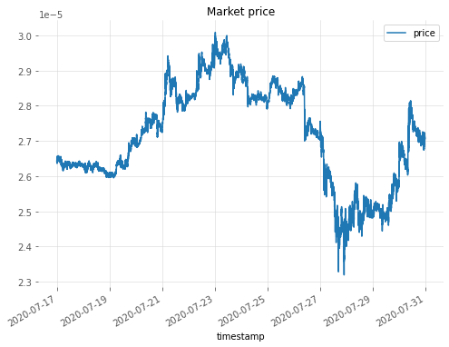

```python
trades.plot(title='Market price', y='price');
```

#### Volume vs LOB depth

Calculate and plot the "average" order book

```python
avg_ob = parsed_ob.sum()/parsed_ob.count()
```

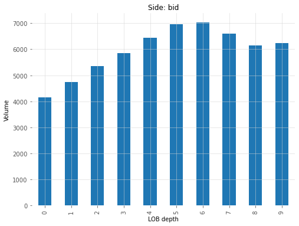

```python
side = 'bids'
book = avg_ob[side]

weights = utils.calculate_weights(book)
(book['volume']*weights).plot.bar(title='Side: bid', xlabel='LOB depth', ylabel='Volume');
```

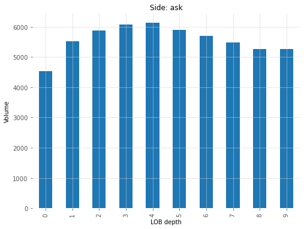

```python
side = 'asks'
book = avg_ob[side]
(book['volume']*weights).plot.bar(title='Side: ask', xlabel='LOB depth', ylabel='Volume');
```

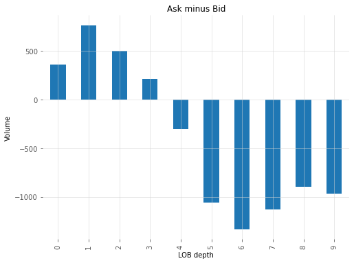

```python
((avg_ob['asks']-avg_ob['bids'])['volume']*weights).plot.bar(title='Ask minus Bid', xlabel='LOB depth', ylabel='Volume');
```

## Feature selection

We will now derive new features from the raw data as they could help uncover correlations/patterns which could help forecast the fair value. The aim is to find a relationship which links the future fair value $N$ steps ahead to the historical LOB data available:

$fair_{t+N} = f(LOB_{t}, LOB_{t-1}, ...)$

### Create new features for each order book

We now calculate:

1. the mid-price and its percent changes (appropriately shifted) in order to be able to use them as target variable
2. the ask/bid ratio for both price and volume
3. the imbalance ratio for both price and volume. The imbalance ratio is defined as $(x_{ask} - x_{bid})/x_{mid}$

```python
parsed_ob['mids'] = (parsed_ob['asks'] + parsed_ob['bids'])/2.
parsed_ob = utils.calculate_pct_changes(parsed_ob, target_side, n_steps_future, keyword='_pct_')

spread = parsed_ob['asks'] - parsed_ob['bids']
parsed_ob['askbid_ratio'] = parsed_ob['asks']/parsed_ob['bids'] - 1
parsed_ob['imbalance_ratio'] = spread/parsed_ob['mids']
```

### Calculate descriptive statistics for each feature

Calculate the weighted mean of price and volume across the levels of the LOB.

```python
for metric in ['askbid_ratio','imbalance_ratio']:
    for col in ['price','volume']:
        parsed_ob[f'{metric}_{col}_weighted_mean'] = parsed_ob[metric].apply( lambda book:
            sum(book[col] * utils.calculate_weights(book,type=orderbook_depth_weights))
            / sum(utils.calculate_weights(book,type=orderbook_depth_weights)) )
```

### Specify targets

Specify the targets of the analysis. If our hypothesis is correct we should find a linear relationship between the target and the (historical) features $f_i$:

$target_{t+N} = [c + a_1 \cdot f_1 + a_2 \cdot f_2 + ... + a_n \cdot f_n]_{t} + [c + a_1 \cdot f_1 + a_2 \cdot f_2 + ... + a_n \cdot f_n]_{t-1} + ...$

```python
targets = [t for t in parsed_ob.columns.values if '_pct_' in t and 'target' not in t]
for t in targets:
    parsed_ob['target_' + t] = parsed_ob[t]
```

### Flatten order books

In order to carry out the analysis we need to "flatten" the order books so that each level of the order book is represented by a separate column. This way we can easily transform each feature to create new ones which might help to predict the target.

```python
to_drop = targets + ['mids']
flat_parsed_ob = utils.flatten_all_books(parsed_ob, to_drop=to_drop,
                                         maxdepth_flatten=maxdepth_flatten)
flat_parsed_ob
```

```
Flattening feature: asks
Flattening feature: bids
Flattening feature: askbid_ratio
Flattening feature: imbalance_ratio
Flattening feature: target_mids_pct_0
Flattening feature: target_mids_pct_5
```

|  | lastUpdated | askbid_ratio_price_weighted_mean | askbid_ratio_volume_weighted_mean | imbalance_ratio_price_weighted_mean | imbalance_ratio_volume_weighted_mean | asks_price_level_0 | asks_price_level_1 | asks_price_level_2 | asks_price_level_3 | asks_price_level_4 | ... | target_mids_pct_5_volume_level_0 | target_mids_pct_5_volume_level_1 | target_mids_pct_5_volume_level_2 | target_mids_pct_5_volume_level_3 | target_mids_pct_5_volume_level_4 | target_mids_pct_5_volume_level_5 | target_mids_pct_5_volume_level_6 | target_mids_pct_5_volume_level_7 | target_mids_pct_5_volume_level_8 | target_mids_pct_5_volume_level_9 |
| --- | --- | --- | --- | --- | --- | --- | --- | --- | --- | --- | --- | --- | --- | --- | --- | --- | --- | --- | --- | --- | --- |
| 1 | 2020-07-17 00:00:30.293 | 0.006077951195 | 95.216377457823 | 0.006057164490 | 0.129558427753 | 0.00002645 | 0.00002646 | 0.00002647 | 0.00002648 | 0.00002649 | ... | -56.023900054318 | 900.564263322884 | -67.376214715410 | -78.312692598407 | 214.674130347861 | -14.386775427705 | 3729.701230228471 | -96.295870240423 | -43.095939541437 | 332.422171602126 |
| 2 | 2020-07-17 00:00:30.429 | 0.005696064107 | 12.132931502401 | 0.005677517033 | 0.060698331709 | 0.00002645 | 0.00002646 | 0.00002647 | 0.00002648 | 0.00002649 | ... | -49.928842504744 | 39.481919332406 | 329.447446785045 | -96.502218159930 | 1397.647058823530 | -30.922277132405 | 1857.344064386318 | -0.412532054856 | 855.312157721796 | -93.554220381497 |
| 3 | 2020-07-17 00:01:04.450 | 0.005658170966 | 4.807230932065 | 0.005639702742 | -0.269652793336 | 0.00002644 | 0.00002646 | 0.00002647 | 0.00002648 | 0.00002649 | ... | -69.245327655548 | 32.827633496186 | 44.568844870277 | -20.173162537896 | -49.673763736264 | -48.751684744240 | 1746.981891348089 | -26.446649570744 | 23.254160147916 | -90.799882801055 |
| 4 | 2020-07-17 00:01:10.753 | 0.005278591847 | 4.644906072570 | 0.005262190319 | -0.110178755809 | 0.00002643 | 0.00002645 | 0.00002646 | 0.00002647 | 0.00002648 | ... | -0.047359696898 | 5.725798894199 | 81.350438892640 | 0.000000000000 | -67.269681742044 | -30.181590482154 | 49.924204143507 | 1051.308900523560 | -60.211557834967 | -86.477174849268 |
| 5 | 2020-07-17 00:01:18.858 | 0.004897152943 | 2.013669986961 | 0.004882686142 | -0.372028741073 | 0.00002643 | 0.00002645 | 0.00002646 | 0.00002647 | 0.00002648 | ... | 7.180570221753 | 63.979019272993 | -29.339504056679 | 799.381387842926 | -90.418124162281 | -98.437500000000 | 33.296964251332 | 177.090909090909 | -42.061745682470 | -90.138190954774 |
| ... | ... | ... | ... | ... | ... | ... | ... | ... | ... | ... | ... | ... | ... | ... | ... | ... | ... | ... | ... | ... | ... |
| 96848 | 2020-07-30 23:58:25.227 | 0.007229176642 | 13.649452908530 | 0.007199312138 | -0.418270221678 | 0.00002710 | 0.00002712 | 0.00002713 | 0.00002717 | 0.00002718 | ... | -8.083867210250 | -25.700687466949 | 129.524232992441 | 1216.624040920716 | -76.126404147636 | 1161.637931034483 | -83.653673432729 | 742.366554684584 | -7.888446215139 | -46.207515199841 |
| 96849 | 2020-07-30 23:58:25.328 | 0.006228613124 | 10.686884864106 | 0.006205477910 | -0.138614138212 | 0.00002709 | 0.00002710 | 0.00002711 | 0.00002712 | 0.00002713 | ... | 13.886010362694 | -66.522349637257 | 74.476722060129 | -6.863442389758 | -17.818930041152 | 0.000000000000 | 48.823836905384 | 0.000000000000 | 0.000000000000 | -13.530349123569 |
| 96850 | 2020-07-30 23:58:25.428 | 0.005709750993 | 4.638994660619 | 0.005689828689 | 0.265893564738 | 0.00002708 | 0.00002709 | 0.00002710 | 0.00002711 | 0.00002712 | ... | 766.938110749186 | 168.767507002801 | -30.515887183149 | 28.866655732327 | -48.277648277648 | -79.576008273009 | 42.849974912193 | -3.040293040293 | 35.144237160456 | -72.546223898445 |
| 96851 | 2020-07-30 23:58:26.225 | 0.006673414751 | 10.621061081675 | 0.006647136258 | -0.156175782429 | 0.00002709 | 0.00002710 | 0.00002712 | 0.00002713 | 0.00002717 | ... | 14.162348877375 | -68.921132693658 | 32.214830757190 | -85.213864306785 | 0.000000000000 | 0.000000000000 | 51.038251366120 | 0.000000000000 | -30.709323421390 | -13.548012764723 |
| 96852 | 2020-07-30 23:58:31.628 | 0.006599422890 | 0.549903308992 | 0.006573281075 | -0.504127771190 | 0.00002707 | 0.00002710 | 0.00002712 | 0.00002713 | 0.00002717 | ... | -11.162361623616 | -65.487009515663 | -4.101969872538 | 94.109904573873 | -60.640508495294 | 4795.555555555556 | 5.101302460203 | -10.931613197854 | -63.781583255896 | -7.248322147651 |

96852 rows × 125 columns

```python
flat_parsed_ob_backup = flat_parsed_ob.copy()
del(parsed_ob); gc.collect()
```

```
0
```

```python
flat_parsed_ob = flat_parsed_ob_backup.copy()
```

### Create additional features

The following snippet creates new features from the original ones. The target might be related to one of the transformed features, and this could help improve the predictive power of the model we are going to fit later on.

- Search for top of the book changes. If the top of the book bid (ask) prices have decreased (increased) an order might have been filled.
- Calculate rolling statistics for each feature, specifically rolling mean and max/min ratio
- Create new features by calculating the percentage change of the original features
- Add lagged features
- Add features powers
- Add features logarithms
- Add binarized features

```python
keywords = ['lastUpdated','target','rolling','lag','pctchange','traded','pow','loge','log10','bin']
flat_parsed_ob = utils.feature_engineering(flat_parsed_ob, keywords)
```

Clean data and check if there are any nulls left

```python
flat_parsed_ob = flat_parsed_ob.replace([np.inf, -np.inf], np.nan)
flat_parsed_ob = flat_parsed_ob.copy().dropna()
flat_parsed_ob.isnull().sum().sum()
```

```
0
```

Check types of columns to make sure subsequent calculations run efficiently

```python
flat_parsed_ob.dtypes.value_counts()
```

```
float64           1066
int64               42
datetime64[ns]       1
dtype: int64
```

## Data analysis

We start with analysing the whole historical LOB dataset to get an understanding of the properties of the independent variables, in particular those that we expect to be able to predict the future fair value.

For this reason the analysis of the whole dataset is only vaguely indicative. We will later perform a rolling cross-validation of the models to get an understanding of their possible predictive power in a scenario similar to the one in which we would actually use them.

### Stationarity and autocorrelation checks

The volume imbalance ratio has positive autocorrelation as shown in the charts below. The partial autocorrelation is significant approximately up to lag 15. This indicates that a positive (negative) imbalance is often followed by periods of persistent positive (negative) imbalance. The imbalance effect is therefore not a transient one, and could help in predicting the target.

```python
results = sm.tsa.stattools.adfuller(flat_parsed_ob['imbalance_ratio_volume_weighted_mean'])
message = "The series is non-stationary"
if results[1] < 0.05:
    for key, value in results[4].items():
        if abs(results[0]) < abs(value):
            message = f'The series is stationary at a significance level of {key}'
            break
print(message)
```

```
The series is non-stationary
```

```python
results = sm.tsa.stattools.kpss(flat_parsed_ob['imbalance_ratio_volume_weighted_mean'], nlags="auto")
message = "The series is non-stationary"
if results[1] < 0.05:
    for key, value in results[3].items():
        if abs(results[0]) < abs(value):
            message = f'The series is stationary at a significance level of {key}'
            break
print(message)
```

```
The series is stationary at a significance level of 2.5%
```

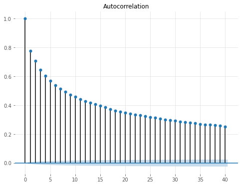

```python
_ = sm.graphics.tsa.plot_acf(flat_parsed_ob['imbalance_ratio_volume_weighted_mean'], lags=40)
```

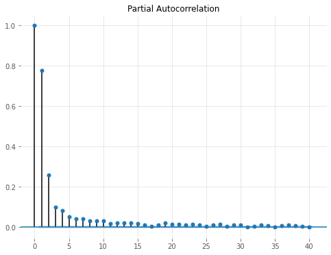

```python
_ = sm.graphics.tsa.plot_pacf(flat_parsed_ob['imbalance_ratio_volume_weighted_mean'], lags=40)
```

### Plot target vs features

Visually inspect the data to possibly find a relationship between the target and some features.

#### Target change vs Volume imbalance

The graph immediately below shows that there is a weak relationship between the volume imbalance ratio and the instantaneous price change of the target variable. This relationship seems to get slightly stronger for longer prediction windows as shown in the second chart: future top of the book prices seem to be more likely to be lower if the current ask volume is higher than the bid volume.

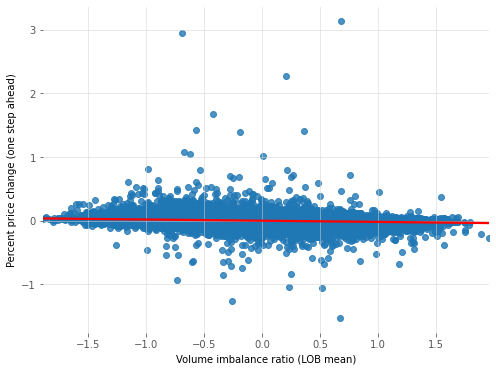

```python
_ = sns.regplot(x='imbalance_ratio_volume_weighted_mean',
                y=f'target_{target_side}_pct_0_price_level_0',
                data=flat_parsed_ob, line_kws=dict(color='red'));
_.set_xlabel('Volume imbalance ratio (LOB mean)');
_.set_ylabel('Percent price change (one step ahead)');
```

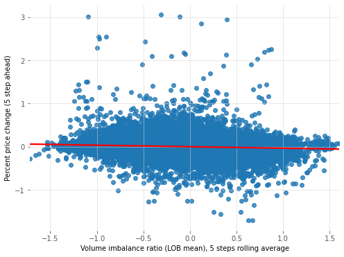

```python
_ = sns.regplot(x='imbalance_ratio_volume_weighted_mean_rolling_5_mean',
                y=f'target_{target_side}_pct_{n_steps_future[-1]}_price_level_0',
                data=flat_parsed_ob, line_kws=dict(color='red'));
_.set_xlabel('Volume imbalance ratio (LOB mean), 5 steps rolling average');
_.set_ylabel(f'Percent price change ({n_steps_future[-1]} step ahead)');
```

### Target change vs Ask bid ratio

The chart below shows that the future mid-price change is on average lower when ask volumes are significantly higher than bid volumes.

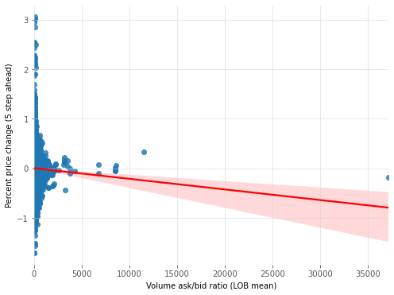

```python
_ = sns.regplot(x='askbid_ratio_volume_weighted_mean',
                y=f'target_{target_side}_pct_5_price_level_0',
                data=flat_parsed_ob, line_kws=dict(color='red'));
_.set_xlabel('Volume ask/bid ratio (LOB mean)');
_.set_ylabel(f'Percent price change ({n_steps_future[-1]} step ahead)');
```

#### Spread vs Volume imbalance

The chart below clearly shows that for higher values of the bid-ask spread both the volume imbalance ratio and the liquidity (fewer data-points for higher spreads) are on average smaller.

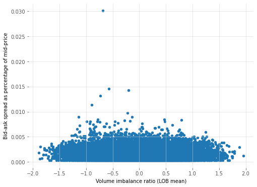

```python
flat_parsed_ob.plot.scatter(x='imbalance_ratio_volume_weighted_mean', y='imbalance_ratio_price_level_0',
                            xlabel='Volume imbalance ratio (LOB mean)', ylabel='Bid-ask spread as percentage of mid-price');
```

## Model selection

Investigate which models could possibly describe the relationship between the current order book and the future top of the book mid-price.

### Prepare data for the analysis

Split the data in train and test sets.

```python
X_train, X_test, y_train, y_test = utils.prepare_data(flat_parsed_ob,
                                                      targets=[f'target_{target_side}_pct_{n_steps_future[-1]}_price_level_0'],
                                                      filter_fun=None)
```

### Linear regression

Check if there are any features that have a linear relationship with the target.

```python
model = sm.OLS(y_train, X_train)
results = model.fit()
results_summary = results.summary()

results_as_html = results_summary.tables[0].as_html()
pd.read_html(results_as_html, header=0, index_col=0)[0]
```

| Dep. Variable: | y | R-squared: | 0.132 |
| --- | --- | --- | --- |
| Model: | OLS | Adj. R-squared: | 0.123 |
| Method: | Least Squares | F-statistic: | 15.820 |
| Date: | Sat, 09 Apr 2022 | Prob (F-statistic): | 0.000 |
| Time: | 17:49:00 | Log-Likelihood: | 52052.000 |
| No. Observations: | 59949 | AIC: | -103000.000 |
| Df Residuals: | 59379 | BIC: | -97830.000 |
| Df Model: | 569 | NaN | NaN |
| Covariance Type: | nonrobust | NaN | NaN |

```python
results_as_html = results_summary.tables[1].as_html()
pd.read_html(results_as_html, header=0, index_col=0)[0].sort_values(by='P>|t|')
```

|  | coef | std err | t | P>\|t\| | [0.025 | 0.975] |
| --- | --- | --- | --- | --- | --- | --- |
| const | 48.8247 | 7.321 | 6.669 | 0.000 | 34.475 | 63.175 |
| imbalance_ratio_volume_level_8_lag_8 | 0.0045 | 0.001 | 5.602 | 0.000 | 0.003 | 0.006 |
| imbalance_ratio_volume_level_8_lag_9 | 0.0044 | 0.001 | 5.533 | 0.000 | 0.003 | 0.006 |
| askbid_ratio_price_level_7_pctchange_61 | 161.5078 | 39.609 | 4.078 | 0.000 | 83.875 | 239.141 |
| imbalance_ratio_volume_level_9_lag_1 | 0.0218 | 0.004 | 5.854 | 0.000 | 0.014 | 0.029 |
| ... | ... | ... | ... | ... | ... | ... |
| askbid_ratio_price_level_2_pctchange_201 | 0.1747 | 13.462 | 0.013 | 0.990 | -26.212 | 26.561 |
| imbalance_ratio_price_level_5_lag_4 | 0.9421 | 83.598 | 0.011 | 0.991 | -162.909 | 164.794 |
| imbalance_ratio_price_level_6_lag_3 | -0.3350 | 91.093 | -0.004 | 0.997 | -178.877 | 178.207 |
| askbid_ratio_price_level_3_pctchange_81 | -0.0549 | 19.018 | -0.003 | 0.998 | -37.330 | 37.220 |
| imbalance_ratio_price_level_3_pctchange_81 | 0.0265 | 19.064 | 0.001 | 0.999 | -37.339 | 37.392 |

1069 rows × 6 columns

#### Residual Analysis

The residuals should ideally:

1. have zero mean
2. be Normally distributed
3. exhibit no autocorrelation

While condition #1 is approximately satisfied, this is not the case for #2 and #3.

Both the Kolmogorov-Smirnov test and the QQ plot show that condition #2 is not satisfied. The residuals are nonetheless approximately distributed symmetrically around the mean.

The Durbin-Watson test, as well as the ACF and PACF charts, show that the residuals are positively autocorrelated: condition #3 is not satisfied.

```python
predictions = results.predict(X_test)
prediction_error = y_test - predictions
pd.DataFrame(prediction_error.describe())
```

|  | 0 |
| --- | --- |
| count | 23194.000000000000 |
| mean | 0.002352179778 |
| std | 0.219006116152 |
| min | -11.074054726947 |
| 25% | -0.067882855451 |
| 50% | 0.000787590469 |
| 75% | 0.069043484067 |
| max | 3.727768332582 |

```python
_, pvalue = sm.stats.diagnostic.kstest_normal(prediction_error)
if pvalue < 0.05: print("The residuals are not Normally distributed; p-value: " + str(pvalue))
```

```
The residuals are not Normally distributed; p-value: 0.0009999999999998899
```

```python
dw = sm.stats.stattools.durbin_watson(prediction_error, axis=0)
if dw < 1: print("The residuals are positively autocorrelated. Durbin-Watson statistic: " + str(dw))
if dw > 3: print("The residuals are negatively autocorrelated. Durbin-Watson statistic: " + str(dw))
```

```
The residuals are positively autocorrelated. Durbin-Watson statistic: 0.571941507029963
```

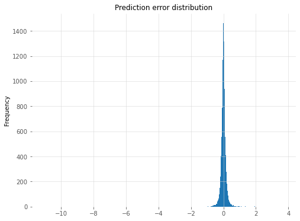

```python
prediction_error.plot(kind='hist',bins=1000, title="Prediction error distribution");
```

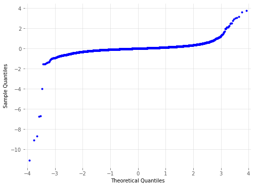

```python
_ = sm.qqplot(prediction_error, marker='.');
```

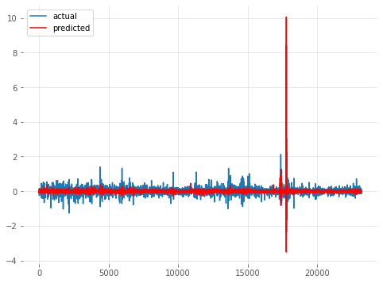

```python
x = range(0,len(y_test))
fig, ax = plt.subplots()
ax.plot(x,y_test,label='actual');
ax.plot(x,predictions,c='r',label='predicted');
legend = ax.legend(loc='upper left')
plt.show();
```

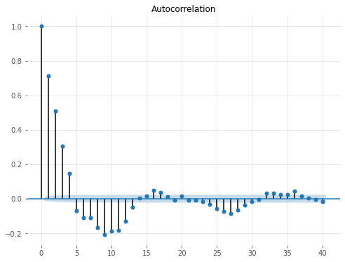

```python
_ = sm.graphics.tsa.plot_acf(prediction_error, lags=40)
```

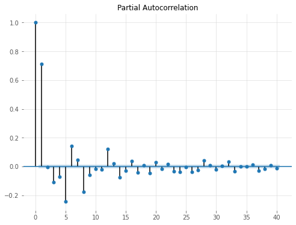

```python
_ = sm.graphics.tsa.plot_pacf(prediction_error, lags=40)
```

### Rolling cross validation

The cross validation setup and the results using a linear regression model are shown below. The cross validation is configured so that the test dataset (orange) is always about $1/5$ of the training dataset (blue). The R-squared and MSE are evaluated for the train set and the test set. The descriptive statistics are shown in the table below, while the rolling R-squared for both the train set and the test set are shown in the subsequent figure.

The train set R-squared values obtained from the cross validation process seem to confirm that the predicted values are actually positively related to the real values. This happens for most of the days in the historical dataset.

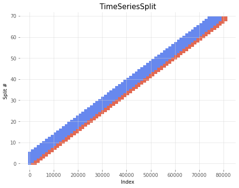

```python
X_train, X_test, y_train, y_test = utils.prepare_data(flat_parsed_ob,
                                                      targets=[f'target_{target_side}_pct_{n_steps_future[-1]}_price_level_0'],
                                                      filter_fun=None, test_size=0.)
n_days = flat_parsed_ob["lastUpdated"].map(pd.Timestamp.date).unique().size
max_train_size = int(np.floor(len(X_train)/n_days))
test_size = int(max_train_size/5)
n_splits = int(len(X_train)/test_size)-1
kfold = model_selection.TimeSeriesSplit(n_splits=n_splits,
                                        test_size=test_size,
                                        max_train_size=max_train_size
                                        )
fig, ax = plt.subplots()
utils.plot_cv_indices(kfold, X_train, y_train, ax);
```

```python
X_train, X_test, y_train, y_test = utils.prepare_data(flat_parsed_ob,
                                                      targets=[f'target_{target_side}_pct_{n_steps_future[-1]}_price_level_0'],
                                                      filter_fun=None, test_size=0.)
scoring = ['r2', 'neg_mean_squared_error']
n_days = flat_parsed_ob["lastUpdated"].map(pd.Timestamp.date).unique().size
scaler = preprocessing.RobustScaler()#MinMaxScaler()
selector = feature_selection.SelectKBest(feature_selection.f_regression, k=20)
models = [('Ridge', pipeline.make_pipeline(scaler, selector, linear_model.Ridge(fit_intercept=False)))]
cv_results, fitted = utils.test_models(X_train, y_train, X_test, y_test, mode='cv',
                                       models=models, scoring=scoring, kfold=kfold)
cv_results.describe()
```

```
Fitting model: Ridge
```

|  | fit_time | score_time | test_r2 | train_r2 | test_neg_mean_squared_error | train_neg_mean_squared_error |
| --- | --- | --- | --- | --- | --- | --- |
| count | 69.000000000000 | 69.000000000000 | 69.000000000000 | 69.000000000000 | 69.000000000000 | 69.000000000000 |
| mean | 0.333873848984 | 0.012919432875 | 0.028822254092 | 0.070229812273 | -0.016471403460 | -0.015131589037 |
| std | 0.018144384567 | 0.001662836451 | 0.059078263947 | 0.034619643888 | 0.023563365223 | 0.013993361944 |
| min | 0.223081588745 | 0.012141942978 | -0.131451745510 | 0.031828395760 | -0.175018441188 | -0.052642739588 |
| 25% | 0.333499431610 | 0.012435436249 | -0.006585886034 | 0.051146566804 | -0.019409458100 | -0.022903501645 |
| 50% | 0.335736989975 | 0.012549638748 | 0.027211790901 | 0.057035963721 | -0.008815412852 | -0.008847181340 |
| 75% | 0.339479684830 | 0.012677192688 | 0.061877578638 | 0.067794161364 | -0.004129877889 | -0.004584193482 |
| max | 0.360774993896 | 0.025242328644 | 0.183978750468 | 0.177001109424 | -0.002426292679 | -0.002778878809 |

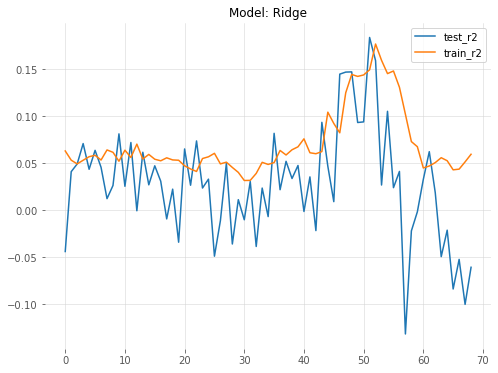

```python
for m in set(cv_results['model']):
    cv_results[cv_results['model']==m][['test_r2','train_r2']].plot(title='Model: ' + m);
```

### Accuracy of the prediction of the linear regression

As shown in the table and in the figure below, the accuracy is greater than 0.5 for most of the days in the historical dataset.

```python
X_train, X_test, y_train, y_test = utils.prepare_data(flat_parsed_ob,
                                                      targets=[f'target_{target_side}_pct_{n_steps_future[-1]}_price_level_0'],
                                                      filter_fun=None, test_size=0)
scoring = metrics.make_scorer(utils.binarize, greater_is_better=True)
n_days = flat_parsed_ob["lastUpdated"].map(pd.Timestamp.date).unique().size
scaler = preprocessing.RobustScaler()
selector = feature_selection.SelectKBest(feature_selection.f_regression, k=30)
models = [('Ridge', pipeline.make_pipeline(scaler, selector, linear_model.Ridge(fit_intercept=False)))]
cv_results, fitted = utils.test_models(X_train, y_train, X_test, y_test, models=models, scoring=scoring, kfold=kfold)
cv_results.describe()
```

```
Fitting model: Ridge
```

|  | fit_time | score_time | test_score | train_score |
| --- | --- | --- | --- | --- |
| count | 69.000000000000 | 69.000000000000 | 69.000000000000 | 69.000000000000 |
| mean | 0.335588002550 | 0.013615846634 | 0.577432354634 | 0.591096794227 |
| std | 0.020117858132 | 0.002543659147 | 0.045609588068 | 0.028600052101 |
| min | 0.216948032379 | 0.010088682175 | 0.464594127807 | 0.512001381454 |
| 25% | 0.333982229233 | 0.012809753418 | 0.548359240069 | 0.579174581247 |
| 50% | 0.338042259216 | 0.012974500656 | 0.577720207254 | 0.590398894837 |
| 75% | 0.343518018723 | 0.013219118118 | 0.603626943005 | 0.607839751338 |
| max | 0.360073804855 | 0.028847694397 | 0.674438687392 | 0.657226731135 |

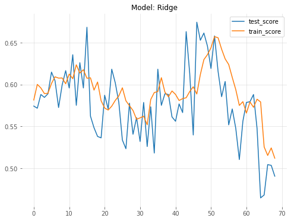

```python
for m in set(cv_results['model']):
    cv_results[cv_results['model']==m][['test_score','train_score']].plot(title='Model: ' + m);
```

### Testing of non-linear models

We now perform a rolling cross-validation of other non-linear models. Before fitting a model we first scale the data, and then discard the features which are weakly correlated with the target according to the p-values provided by a linear regression. We then perform the rolling cross validation using only the remaining features.

As shown in the table below, non-linear models perform worse than the linear regression. This indicates that the relationship between the independent variables and the target variable is inherently linear. Other models are likely overfitting the past data (high R-squared on train data), and therefore perform poorly on unseen data (low R-squared on test data).

```python
X_train, X_test, y_train, y_test = utils.prepare_data(flat_parsed_ob,
                                                      targets=[f'target_{target_side}_pct_{n_steps_future[-1]}_price_level_0'],
                                                      filter_fun=None, test_size=0)
scoring = ['r2', 'neg_mean_squared_error']
n_days = flat_parsed_ob["lastUpdated"].map(pd.Timestamp.date).unique().size
scaler = preprocessing.MaxAbsScaler()
selector = feature_selection.SelectKBest(feature_selection.f_regression, k=30)
models = [
       ('RF',   pipeline.make_pipeline(scaler, selector, ensemble.RandomForestRegressor(n_jobs=-1))),
       ('GBR', pipeline.make_pipeline(scaler, selector, ensemble.GradientBoostingRegressor())),
       ('XGB', pipeline.make_pipeline(scaler, selector, xgboost.XGBRegressor()))
    ]
cv_results, fitted = utils.test_models(X_train, y_train, X_test, y_test, models=models, scoring=scoring, kfold=kfold)
cv_results.groupby('model').agg([np.mean, np.std]).drop(['fit_time', 'score_time'],axis=1)
```

```
Fitting model: RF
Fitting model: GBR
Fitting model: XGB
```

| model | test_r2 mean | test_r2 std | train_r2 mean | train_r2 std | test_neg_mean_squared_error mean | test_neg_mean_squared_error std | train_neg_mean_squared_error mean | train_neg_mean_squared_error std |
| --- | --- | --- | --- | --- | --- | --- | --- | --- |
| GBR | -0.035045437279 | 0.126602822863 | 0.275395881971 | 0.095452032435 | -0.017260935830 | 0.023765452648 | -0.011328787795 | 0.010029123550 |
| RF | -0.081334531733 | 0.161601914501 | 0.860985559525 | 0.097174713448 | -0.017709898251 | 0.023942569538 | -0.002087620088 | 0.001902349882 |
| XGB | -0.228866571154 | 0.239549250860 | 0.810262931564 | 0.122869576106 | -0.019637913009 | 0.024934347772 | -0.002763408650 | 0.002724918205 |

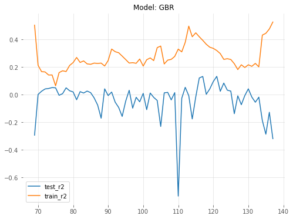

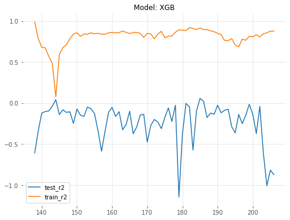

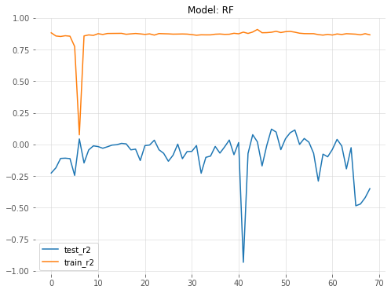

```python
for m in set(cv_results['model']):
    cv_results[cv_results['model']==m][['test_r2','train_r2']].plot(title='Model: ' + m);
```

### Logistic regression as benchmark

The logistic regression is not suitable for our end goal, as we need to predict a continuous value, not a discrete one. We can nonetheless run a rolling cross validation using a logistic regression to compare its results to the accuracy of the linear regression's prediction. To do so we transform the target variable in a discrete one by considering only the sign of the prediction: positive values are considered as +1, and negative values are considered as -1.

As shown in the table below, the accuracy of the prediction of the logistic regression is comparable to the accuracy of the "binarized" linear regression. This increases our confidence in the validity of the results of the cross validation of the linear regression model.

```python
X_train, X_test, y_train, y_test = utils.prepare_data(flat_parsed_ob,
                                                      targets=[f'target_{target_side}_pct_{n_steps_future[-1]}_price_level_0'],
                                                      filter_fun=utils.discretify, add_constant=False, test_size=0)
scoring = ['accuracy']
scaler = preprocessing.MaxAbsScaler()
selector = feature_selection.SelectKBest(feature_selection.f_classif, k=30)
models = [('LogReg', pipeline.make_pipeline(scaler, selector, linear_model.LogisticRegression(max_iter=1000)))]
cv_results, fitted = utils.test_models(X_train, y_train, X_test, y_test,
                                       type='classification', models=models,
                                       scoring=scoring, kfold=kfold)
cv_results.describe()
```

```
Filtering target
Fitting model: LogReg
```

|  | fit_time | score_time | test_accuracy | train_accuracy |
| --- | --- | --- | --- | --- |
| count | 69.000000000000 | 69.000000000000 | 69.000000000000 | 69.000000000000 |
| mean | 0.169621491778 | 0.011826076369 | 0.589784986609 | 0.607050206462 |
| std | 0.027328752996 | 0.000737363203 | 0.034070475403 | 0.019191981563 |
| min | 0.047887563705 | 0.011236190796 | 0.504317789292 | 0.574339492316 |
| 25% | 0.153435707092 | 0.011511325836 | 0.570811744387 | 0.594178082192 |
| 50% | 0.170368194580 | 0.011587858200 | 0.589810017271 | 0.604904161630 |
| 75% | 0.187912702560 | 0.011782407761 | 0.608808290155 | 0.615783111725 |
| max | 0.226779699326 | 0.015849828720 | 0.671848013817 | 0.666551545502 |

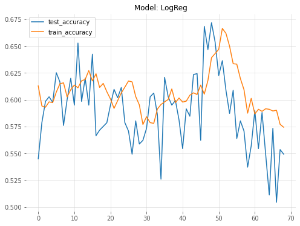

```python
for m in set(cv_results['model']):
    cv_results[cv_results['model']==m][['test_accuracy','train_accuracy']].plot(title='Model: ' + m);
```

# Spread estimation

The spread is estimated as suggested in [Avellaneda and Stoikov](https://www.math.nyu.edu/~avellane/HighFrequencyTrading.pdf) [1].

The charts below clearly show that the spread should increase proportionally to the market volatility. The remaining parameters ($\gamma, \kappa$) can be used to trim the risk we are willing to take. The charts below are produced by using the values suggested in the original paper.

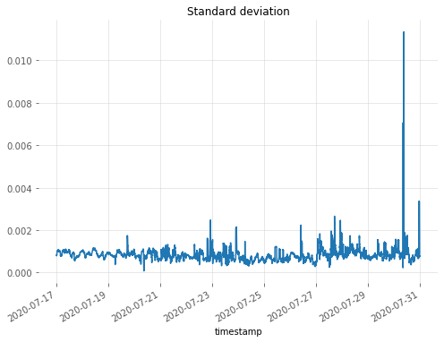

```python
std_window=200
prices = trades.drop_duplicates()['price']
std = prices.pct_change().rolling(std_window).std().fillna(0)
prices = prices[std>0]
std = std[std>0]
std.plot(title="Standard deviation");
```

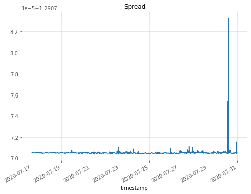

```python
spread = utils.calculate_spread(0, T=1, gamma=gamma, sigma=std, k=kappa)
spread.plot(title="Spread");
```

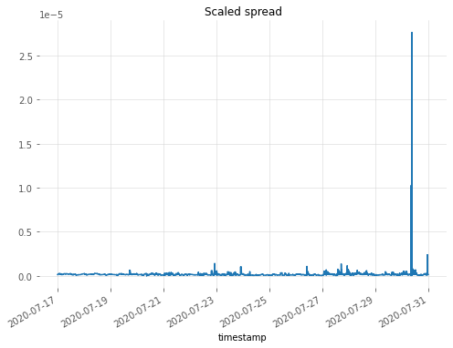

```python
spread = ((spread - spread.min())/(spread.max()-spread.min())).fillna(0)
spread = spread*prices
spread.plot(title="Scaled spread");
```

## Visual inspection of the market, bid, and ask prices

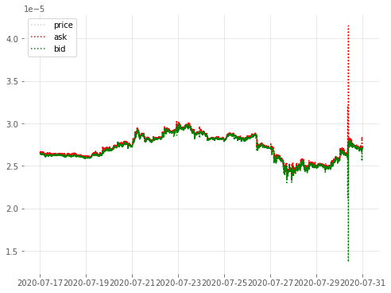

```python
ask = prices + spread/2
bid = prices - spread/2
fig, ax = plt.subplots()
ax.plot(prices,linestyle=':',color='lightgrey',label='price');
ax.plot(ask,':r',label='ask');
ax.plot(bid,':g',label='bid');
legend = ax.legend(loc='upper left')
plt.show();
```

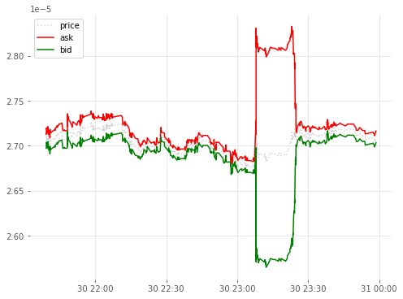

```python
fig, ax = plt.subplots()
ax.plot(prices[-1000:],linestyle=':',color='lightgrey', label='price');
ax.plot(ask[-1000:],'-r',label='ask');
ax.plot(bid[-1000:],'-g',label='bid');
legend = ax.legend(loc='upper left')
plt.show();
```

# Conclusions

The analysis has confirmed our initial hypothesis of a linear relationship between the target variable (fair price $N$ steps ahead) and the independent variables (historical prices and volumes in the first 10 levels of the order book). The results of the cross validation indicate that such a relationship could be exploited effectively to forecast the fair price and to provide quotes around it.

An example implementation of the entire predictive algorithm described in this document is provided in the module `quoter.py` attached to this document. The `Quoter` class contained in the module requires the historical LOB and trades data to fit the model. Once the `Quoter` is initialized, it is ready to predict future values in an "online" fashion. Since the predictive model is based on lagged features as well as on features' percent changes, the prediction requires a number of past LOBs at least equal to the maximum lag/percent change used when training the model.

## Further work

Although the results of the analysis are encouraging, additional work is necessary before considering deploying the predictive algorithm to production:

1. A back-test should be performed to simulate the hypothetical P&L of a strategy using the predictive values calculated as described in this document
2. Additional analyses of the outliers should be performed before fitting the model
3. Additional analyses of the residuals should be performed to possibly address their positive autocorrelation and non-Normality
4. Trades data should be used as additional features
5. Perform a rolling analysis of the residuals of the linear regression
6. Non-linear models could be further investigated using a grid search (with cross validation) to understand if the overfitting problem highlighted by the results in this document could be mitigated
7. A dimensionality analysis (for example PCA) could be performed to understand if the number of independent variables could be reduced further
8. A grid search could be performed to possibly find the best forecast window (i.e., the optimal $N$ steps ahead) to employ in production
9. The spread estimation model parameters should be calibrated according to both the desired risk level and the historical data
10. The spread estimation model might be improved by using a volatility model (for example EWMA, GARCH, EGARCH) instead of the historical volatility
11. All the functions used to transform and manipulate the data should be optimized to minimize execution time
12. Appropriate logging should be put in place to catch unexpected behaviour

# References

1. [Avellaneda M., Stoikov S. High frequency trading in a limit order book. Quantitative Finance, Vol. 8, No. 3, April 2008](https://www.math.nyu.edu/~avellane/HighFrequencyTrading.pdf)
2. [Chordia T., Roll R., Subrahmanyam A. Order Imbalance, Liquidity, and Market Returns. Journal of Financial Economics, Vol. 64, no. 1, 2002](https://catalogimages.wiley.com/images/db/pdf/9780470181690.excerpt.pdf)
3. [Cartea A., Donnelly R., Jaimungal S. Enhancing Trading Strategies with Order Book Signals. SSRN, October 2015](https://papers.ssrn.com/sol3/papers.cfm?abstract_id=2668277)